# Homework 08

The former kernel-tuning question has moved to Homework 09.

Solutions for Questions 1 and 2 will be available after Monday, October 19, 2026. No solution can be provided for Question 3.

For Questions 1 and 2, use either R or Python.

## Question 1: Boundary and margin

Use `margin-geometry-20.csv` from the combined ZIP, which contains 20 observations with predictors $x_1,x_2$ and class labels $y\in\{-1,1\}$. Consider the score

$$f(x)=0.8x_1+0.6x_2.$$

Since $\|(0.8,0.6)\|_2=1$, the lines $f(x)=\pm1$ are each a distance 1 from the decision boundary $f(x)=0$.

Use the observation numbers supplied in the data. Set the $x_1$ axis to $[-3.2,3.2]$, set the $x_2$ axis to $[-3,3]$, and use an equal aspect ratio. Do not fit a new classifier for this question.

1. Calculate the distance from every observation to the decision boundary and its functional margin $yf(x)$. In a table, report these values and whether each observation is inside, on, or beyond the margin for its class. Compare $yf(x)$ with 1 to make this distinction.

   Signed Distance: $\frac{f(x)}{||\beta||}$

   Since the Euclidean norm of $\beta$ is $\sqrt{(0.8)^2 + (0.6)^2} = 1$, the signed distance simplifies to $f(x)$. The absolute value of the signed distance is the distance to the hyperplane (Week 8 Lecture: Maximizing the Separation Margin).

   **Show the workflow**

   ```r
   # Import the csv file
   df_geo20 <- read.csv("data/margin-geometry-20.csv")

   # Calculate the score
   x1 <- df_geo20$x1
   x2 <- df_geo20$x2
   score <- 0.8 * x1 + 0.6 * x2

   # Calculate the distance from every observation to the decision boundary
   beta <- matrix(c(0.8, 0.6), nrow = 1, ncol = 2)
   distance <- abs(score)

   # Calculate functional margin
   y <- df_geo20$y
   func_margin <- y * score

   # Compare each observation to the functional margin and determine if the observation is inside, on, or beyond the margin
   compare_position <- rep(NA, times = length(score))

   for (i in seq_along(compare_position)){
     if (func_margin[i] < 1){
       compare_position[i] = "Inside"
     } else if (func_margin[i] == 1){
       compare_position[i] = "On"
     } else if (func_margin[i] > 1){
       compare_position[i] = "Beyond"
     }
   }

   data.frame(
     distance = distance,
     functional_margin = func_margin,
     margin_position = compare_position
   )
   ```

   ```
      distance functional_margin margin_position
   1      1.00              1.00              On
   2      1.35              1.35          Beyond
   3      1.50              1.50          Beyond
   4      1.70              1.70          Beyond
   5      1.90              1.90          Beyond
   6      2.20              2.20          Beyond
   7      2.40              2.40          Beyond
   8      0.64              0.64          Inside
   9      0.20              0.20          Inside
   10     0.20             -0.20          Inside
   11     1.00              1.00              On
   12     1.30              1.30          Beyond
   13     1.55              1.55          Beyond
   14     1.75              1.75          Beyond
   15     1.95              1.95          Beyond
   16     2.15              2.15          Beyond
   17     2.45              2.45          Beyond
   18     0.64              0.64          Inside
   19     0.24              0.24          Inside
   20     0.20             -0.20          Inside
   ```

2. Plot the observations, the boundary $f(x)=0$, and the margin lines $f(x)=\pm1$. Distinguish the two classes and identify the observations inside the margin in your plot.

   To plot the boundary line, plug in $f(x) = 0$ and solve for $x_2$.

   $$0 = 0.8x_1+0.6x_2.$$

   $$-0.6x_2 = 0.8x_1$$

   $$x_2 = -\frac{4}{3}x_1$$

   To plot the margin lines, plug in $f(x) = \pm 1$ and solve for $x_2$.

   $$\pm1 = 0.8x_1+0.6x_2$$

   $$-0.6x_2 = 0.8x_1 \mp 1$$

   $$x_2 = -\frac{4}{3}x_1 \pm -\frac{5}{3}$$

   **Show the workflow**

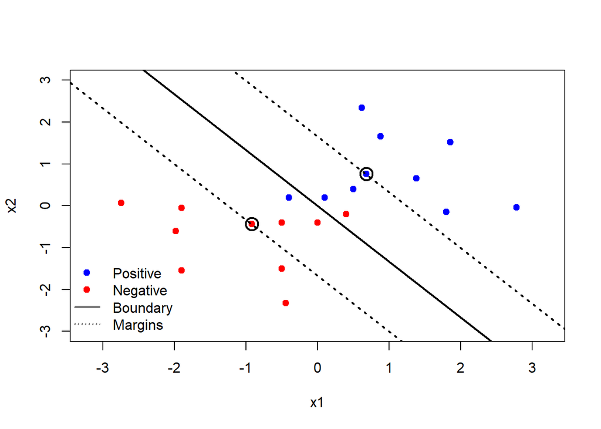

   ```r
   plot(x = x1, y = x2,
        xlim = c(-3.2, 3.2),
        ylim = c(-3, 3),
        col = ifelse(y == 1, "blue", "red"),
        pch = 19)

   # Plot the boundary line
   abline(a = 0, b = -4/3, lwd = 2)

   # Plot the margin lines
   abline(a = -5/3, b = -4/3, lty = 3, lwd = 2)
   abline(a = 5/3, b = -4/3, lty = 3, lwd = 2)

   # Circle the observations that are on the margin lines
   points(x1[compare_position == "On"], x2[compare_position == "On"],
          pch = 1, cex = 2, lwd = 2)

   legend(
     "bottomleft",
     c("Positive", "Negative", "Boundary", "Margins"),
     col = c("blue", "red", "black", "black"),
     pch = c(19, 19, NA, NA),
     lty = c(NA, NA, 1, 3),
     bty = "n"
   )
   ```

   **Show the workflow**

   ```r
   # Identify the observations inside the margin of your plot
   df_geo20$observation[compare_position == "Inside"]
   ```

   ```
   [1]  8  9 10 18 19 20
   ```

   The observations inside the margins are 8, 9, 10, 18, 19, and 20. These can be seen as three red dots and three blue dots inside the dotted lines on the graph.
3. Report how many observations are inside, on, and beyond the margin. Which observations are misclassified by this decision rule?

   **Show the workflow**

   ```r
   # Count how many observations are inside, on, or beyond the margin
   inside_count <- sum(compare_position == "Inside")
   on_count <- sum(compare_position == "On")
   beyond_count <- sum(compare_position == "Beyond")

   data.frame(
     inside = inside_count,
     on = on_count,
     beyond = beyond_count
   )
   ```

   ```
     inside on beyond
   1      6  2     12
   ```

   **Show the workflow**

   ```r
   # Find which observations are misclassified by the decision rule
   predicted_class <- ifelse(score >= 0, 1, -1)
   df_geo20$observation[predicted_class != y]
   ```

   ```
   [1] 10 20
   ```

   Observations 10 and 20 are misclassified by this decision rule. We can visually see this on the plot above. There is one red observation that crosses the boundary line towards the blue observations, and there is one blue observation that crosses the boundary line towards the red observations.

## Question 2: Margin in four dimensions

Use `margin-geometry-4d.csv` from the combined ZIP, which contains 50 observations with four predictors and class labels $y\in\{-1,1\}$. Consider the linear score

$$f(\mathbf{x})=\beta_0+\mathbf{x}^{\mathsf T}\boldsymbol{\beta},
\qquad
\beta_0=-1,
\quad
\boldsymbol{\beta}=(1,2,-2,4)^{\mathsf T}.$$

1. Project the observations onto the direction of $\boldsymbol{\beta}$ and plot their positions on one axis. Distinguish the two classes and mark the decision boundary. Use the plot to calculate the geometric margin $M$, the distance from the boundary to the closest observation.

   **Show the workflow**

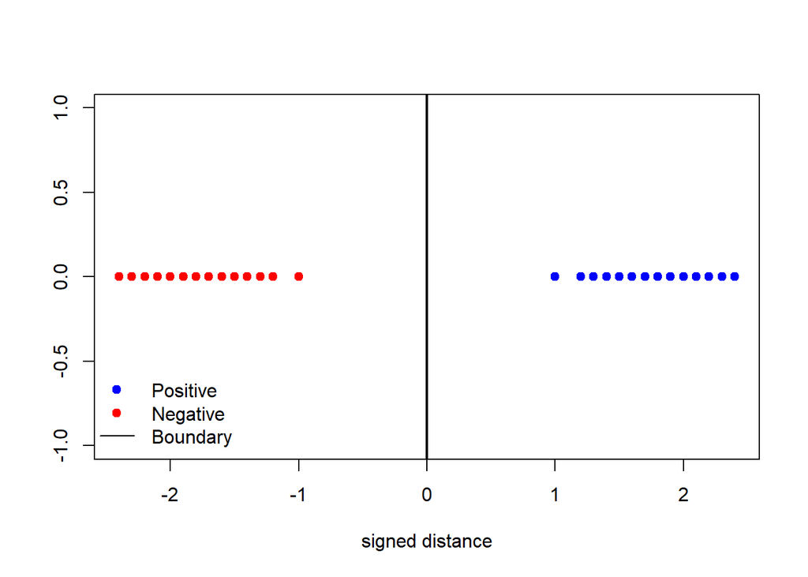

   ```r
   # Import the csv file
   df_geo4d <- read.csv("data/margin-geometry-4d.csv")
   x1 <- df_geo4d$x1
   x2 <- df_geo4d$x2
   x3 <- df_geo4d$x3
   x4 <- df_geo4d$x4
   X <- cbind(x1, x2, x3, x4)

   beta0 <- -1
   beta <- matrix(c(1, 2, -2, 4))

   y <- df_geo4d$y

   # Use signed distance formula to calculate projection
   projection <- (beta0 + (X %*% beta)) / norm(beta, type = "F")

   # Plot projection positions on on axis
   plot(projection, rep(0, length(projection)),
        xlab = "signed distance",
        ylab = "",
        col = ifelse(y == 1, "blue", "red"),
        pch = 19)

   # On the decision boundary, f(x) = 0, so the signed distance is 0
   abline(v = 0, lwd = 2)

   legend(
     "bottomleft",
     c("Positive", "Negative", "Boundary"),
     col = c("blue", "red", "black"),
     pch = c(19, 19, NA),
     lty = c(NA, NA, 1),
     bty = "n"
   )
   ```

   **Show the workflow**

   ```r
   # Calculate geometric margin (smallest distance between boundary and observation)
   # Absolute value of signed distance is the distance to the hyperplane
   M <- min(abs(projection))
   paste("Geometric margin M =", M)
   ```

   ```
   [1] "Geometric margin M = 1"
   ```

2. Express the same decision boundary using the SVM normalization in which the smallest functional margin $y_i f(\mathbf{x}_i)$ is set to 1. What are the corresponding values of $\boldsymbol{\beta}$ and $\beta_0$?

   Find the smallest margin under the given score, then rescale $\boldsymbol{\beta}$ and $\beta_0$ so the minimum functional margin becomes 1.

   **Show the workflow**

   ```r
   # Find the smallest margin
   fx <- beta0 + X %*% beta
   min_margin <- min(y * fx)
   scale <- 1 / min_margin

   beta0_SVM <- scale * beta0
   beta_SVM <- scale * beta
   fx_SVM <- beta0_SVM + X %*% beta_SVM

   # Check if the minimum functional margin is equal to 1
   check_min_margin <- min(y * fx_SVM)
   paste("The minimum functional margin is", check_min_margin)
   ```

   ```
   [1] "The minimum functional margin is 1"
   ```

   The rescaled values are $\quad \beta_0 = -0.2, \quad \beta = (0.2, 0.4, -0.4, 0.8)^T$.

## Question 3: Peer review of a Homework 7 skill

The instructor’s GitHub account, **rqzhu-aide**, will open a **GitHub Issue** in the repository containing your Homework 7 submission. It will link to **one** assigned student’s repository.

1. **Use the skill.** Find the complete skill definition in the assigned student’s Homework 7 report. Copy it without changes into a local `SKILL.md` file in your own folder. You do not need to install it. Give your agent the path to the file and explicitly ask it to follow that skill while analyzing the `SAheart` data, using the response and predictor coding from Homework 7. Provide the necessary data information, but no additional preferences about methods, figures, model selection, or report style. Let the skill direct the analysis.

   Monitor the time, your token use, and your weekly quota while the agent works. If the run is taking too long or using your allowance too quickly, you may send a **steer message** asking the agent to finish immediately, or stop the run and summarize what you observed. A steer message redirects an agent while it is working; learn how to send one in your AI tool before starting.

   When running ryanskim04’s skill to analyze the `SAheart` dataset, my AI agent took approximately 5 minutes to finish the analysis. Running this skill file costed 3.4 tokens, and I’m given 200 tokens per month. Assuming every month has 4 weeks, my weekly quota is 50 tokens. Therefore, running ryanskim04’s skill costed about 6.8% of my weekly quota. The AI agent was able to sucessfully run the LDA-QDA analysis for the `SAheart` dataset.
2. **Write a peer review.** Read the student’s submitted report and what the skill produced in your run. Give a brief overall assessment, followed by **three major items the author could improve**. You may comment on any aspect of the skill or report. For each item, explain what you observed, why it matters, and what you recommend changing. If you stopped the run early, explain where and why. Write the review yourself, without AI assistance.

   ryanskim04’s LDA-QDA analysis skill produced a report that fits in one page. The skill produced an outcome, a design and selection section, a table for training cross-validation, a graph to show the difference between the misclassification rate between LDA and QDA, a one-time held-out evaluation, and a table that displayed observed and predicted values. ryanskim04’s skill file followed the requirements outlined in Homework 7 Question 4. The skill can only be invoked if the user calls for it, and it can be applied to any dataset, not just the `SAheart` dataset. Overall, the report is concise and easy to follow.

   Three items the author could improve on:
   1. The report can be given slightly more context for readers who are unaware of what the `SAheart` dataset means or why the author is running a LDA vs. QDA analysis. The author could provide a brief background in the beginning explaining what the report entails. In addition, it may be helpful to state what the predictors and response variables abbreviations stand for.
   2. A brief summary/conclusion of the analysis towards the end of the report may be helpful for readers. Rather than stating “The CV result favored LDA by about 3.8 percentage points”, it may be helpful to say something along the lines of “LDA had the better predictive performance than QDA because LDA’s misclassification rate is about 3.8 percentage points lower than QDA’s misclassification rate”. I can see that the title of the graph says “(lower is better)”, but explaining it in text may help readers.
   3. For the observed/predicted table, it may be helpful for readers to label the 0’s and 1’s as False Positive, True Positive, False Negative, and True Negative (or added in parentheses). Specify what positive means here. This gives context on which values are misclassified.
3. **Share your review.** Open a GitHub Issue in the assigned student’s Homework 7 repository containing your review. Copy the same review into your Homework 8 submission report and include a link to the GitHub Issue.

   https://github.com/ryanskim04/stat432-fall2026/issues/5